# Simulating Data in R

Carlos Calvo Hernandez

5/15/2019

# Simulating Data

Simulating data can be a very useful learning tool. It can help each of us better understand the “real world” data we collect by allowing us to mimic the structure of data we hope to collect or data we have collected. It can help us better understand the analyses and models we wish to use, as well as the algorithms upon which those rely.

## Univariate Data Simulation

There are a large number of theoretical distributions which can be simulated using base R. The function `rnorm` creates *random* sampling from a Normal Distribution, given a **mean** and a **standard deviation**.

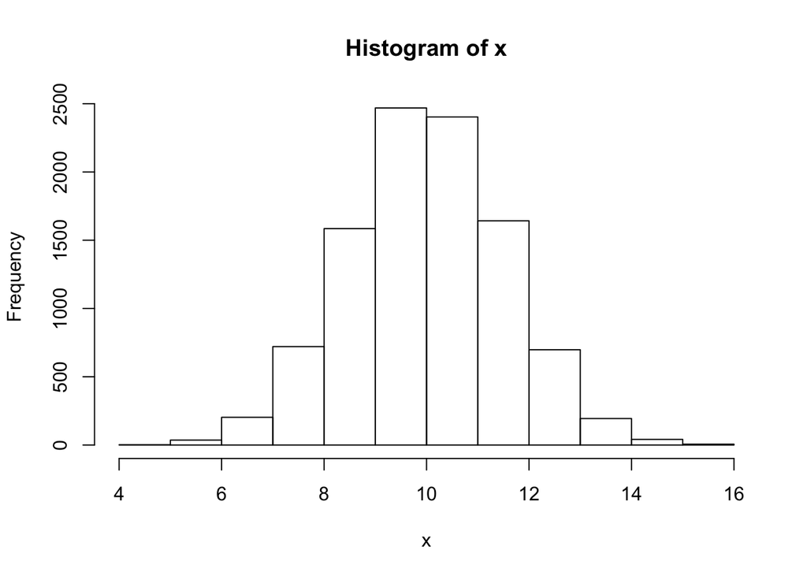

```r
x <- rnorm(n = 10000, mean = 10, sd = 1.5)
hist(x)
```

```r
mean(x)
```

```
## [1] 10.00168
```

```r
sd(x)
```

```
## [1] 1.521057
```

When no mean or standard deviation are provided, the default values are mean of zero and standard deviation of one.

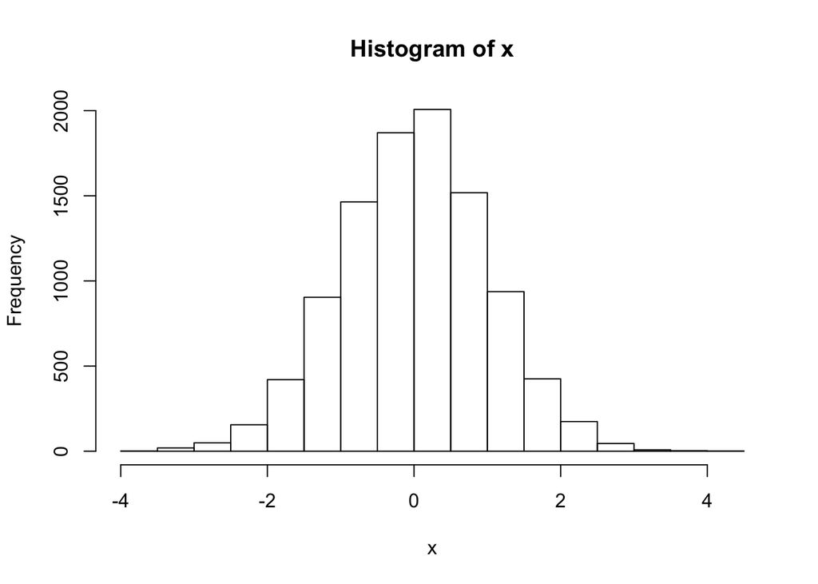

```r
x <- rnorm(10000)
hist(x)
```

```r
mean(x)
```

```
## [1] 0.01189149
```

```r
sd(x)
```

```
## [1] 0.9931725
```

There are associated functions for doing the same thing with other theoretical distributions; such as: `rbeta` (Beta distribution), `rexp` (Exponential distribution), `rchisq` (non-central Chi-Squared distribution), `rpois` (Poisson distribution), `rf` (F distribution), `rt` (Student`s t distribution), etc.

Each distribution also has three other functions which provide density, distribution function, and quantile. So, for the Normal distribution(s) there are four standard functions: `rnorm`, `dnorm` (density), `pnorm` (distribution function), and `qnorm` (for quantiles).

## Common Regression-style simulation

We want to demonstrate a couple of commonly used single-outcome prediction/explanation models. First, Ordinary Least Squares, OLS, linear regression. These examples are “perfect” because the assumptions of the models are met: only linear relationships, homoscedasticity of variances, normal distribution of residuals, no multicollinearity, no measurement error, and only the correct variables are included in the model, i.e. no model misspecifications [errors of omission or errors of inclusion].

```r
x <- rnorm(100, 10, 1.5)
Zx <- scale(x)
Zy <- .8*Zx + rnorm(100, 0, sqrt(1 - (.8^2)))
```

```r
cor(Zx, Zy)
```

```
##           [,1]
## [1,] 0.7448082
```

```r
summary(lm(Zy ~ 0 + Zx))
```

```
##
## Call:
## lm(formula = Zy ~ 0 + Zx)
##
## Residuals:
##      Min       1Q   Median       3Q      Max
## -2.15705 -0.45295  0.02071  0.49063  1.77047
##
## Coefficients:
##    Estimate Std. Error t value Pr(>|t|)
## Zx  0.75311    0.06782   11.11   <2e-16 ***
## ---
## Signif. codes:  0 '***' 0.001 '**' 0.01 '*' 0.05 '.' 0.1 ' ' 1
##
## Residual standard error: 0.6748 on 99 degrees of freedom
## Multiple R-squared:  0.5547, Adjusted R-squared:  0.5502
## F-statistic: 123.3 on 1 and 99 DF,  p-value: < 2.2e-16
```

We can see that 0.7448082 is very close to the value we chose (0.8) to generate the data.

To see the more familiar non-standardized version, simply use the original ‘x’ variable as the predictor and apply the same ‘scaling’ or parameters (i.e. mean & standard deviation) to the outcome, ‘y’.

```r
y <- (1.5*Zy) + 10
cor(x, y)
```

```
##           [,1]
## [1,] 0.7448082
```

```r
summary(lm(y ~ x))
```

```
##
## Call:
## lm(formula = y ~ x)
##
## Residuals:
##     Min      1Q  Median      3Q     Max
## -3.2508 -0.6946  0.0159  0.7208  2.6405
##
## Coefficients:
##             Estimate Std. Error t value Pr(>|t|)
## (Intercept)  2.29897    0.70569   3.258  0.00154 **
## x            0.76155    0.06892  11.050  < 2e-16 ***
## ---
## Signif. codes:  0 '***' 0.001 '**' 0.01 '*' 0.05 '.' 0.1 ' ' 1
##
## Residual standard error: 1.017 on 98 degrees of freedom
## Multiple R-squared:  0.5547, Adjusted R-squared:  0.5502
## F-statistic: 122.1 on 1 and 98 DF,  p-value: < 2.2e-16
```

We can now add complexity, such as a second predictor and an interaction term.

```r
x1 <- rnorm(100, 10, 1.5)
Zx1 <- scale(x1)
x2 <-rnorm(100, 10, 1.5)
Zx2 <- scale(x2)
x3 <- x1*x2
Zx3 <- scale(x3)
Zy <- (.7*Zx1) + (.4*Zx2) + (.2*Zx3) +rnorm(100, 0, sqrt(.31))
y <- (1.5*Zy) + 10
df.1 <- data.frame(x1, x2, x3, y)
rm(x, Zx, Zx1, x1, Zx2, x2, Zx3, x3, Zy, y)
```

Checking the results:

```r
summary(lm(y ~ x1 + x2 + x3, data = df.1))
```

```
##
## Call:
## lm(formula = y ~ x1 + x2 + x3, data = df.1)
##
## Residuals:
##      Min       1Q   Median       3Q      Max
## -2.18057 -0.63058  0.05117  0.70431  2.08284
##
## Coefficients:
##             Estimate Std. Error t value Pr(>|t|)
## (Intercept) -2.85183    3.82607  -0.745   0.4579
## x1           0.76328    0.37476   2.037   0.0444 *
## x2           0.39660    0.36326   1.092   0.2777
## x3           0.01214    0.03550   0.342   0.7330
## ---
## Signif. codes:  0 '***' 0.001 '**' 0.01 '*' 0.05 '.' 0.1 ' ' 1
##
## Residual standard error: 0.8821 on 96 degrees of freedom
## Multiple R-squared:  0.7671, Adjusted R-squared:  0.7598
## F-statistic: 105.4 on 3 and 96 DF,  p-value: < 2.2e-16
```

```r
summary(lm(scale(y) ~ 0 + scale(x1) + scale(x2) + scale(x1)*scale(x2), data = df.1))
```

```
##
## Call:
## lm(formula = scale(y) ~ 0 + scale(x1) + scale(x2) + scale(x1) *
##     scale(x2), data = df.1)
##
## Residuals:
##      Min       1Q   Median       3Q      Max
## -1.21196 -0.35080  0.02799  0.39085  1.15674
##
## Coefficients:
##                     Estimate Std. Error t value Pr(>|t|)
## scale(x1)            0.72424    0.05085  14.242  < 2e-16 ***
## scale(x2)            0.46433    0.04903   9.471 1.86e-15 ***
## scale(x1):scale(x2)  0.01600    0.04654   0.344    0.732
## ---
## Signif. codes:  0 '***' 0.001 '**' 0.01 '*' 0.05 '.' 0.1 ' ' 1
##
## Residual standard error: 0.4876 on 97 degrees of freedom
## Multiple R-squared:  0.7671, Adjusted R-squared:  0.7599
## F-statistic: 106.5 on 3 and 97 DF,  p-value: < 2.2e-16
```

Another common regression model is the binary logistic regression model. We will use the `invlogit` function from the `arm` package.

```r
library(arm)
```

Since we are going to be dealing with a binary outcome variable, we use the `rbinom` function.

```r
x1 <- rnorm(100)
x2 <- rnorm(100)
x3 <- rnorm(100)
b0 <- 1
b1 <- 1.5
b2 <- 2
b3 <- 0.5
y <- rbinom(100, 1, invlogit(b0 + b1*x1 + b2*x2 + b3*x3))
df.2 <- data.frame(x1, x2, x3, y)
rm(x1, x2, x3, b0, b1, b2, b3, y)
summary(df.2)
```

```
##        x1                 x2                 x3                 y
##  Min.   :-2.91428   Min.   :-2.76331   Min.   :-2.79386   Min.   :0.0
##  1st Qu.:-0.45840   1st Qu.:-0.56819   1st Qu.:-0.74289   1st Qu.:0.0
##  Median : 0.01819   Median : 0.07148   Median : 0.08782   Median :1.0
##  Mean   : 0.02204   Mean   : 0.12672   Mean   : 0.00417   Mean   :0.6
##  3rd Qu.: 0.59162   3rd Qu.: 0.84260   3rd Qu.: 0.68600   3rd Qu.:1.0
##  Max.   : 2.61839   Max.   : 3.14920   Max.   : 4.60624   Max.   :1.0
```

```r
df.3 <- df.2
df.3[,4] <- as.factor(df.2[,4])
summary(df.3)
```

```
##        x1                 x2                 x3           y
##  Min.   :-2.91428   Min.   :-2.76331   Min.   :-2.79386   0:40
##  1st Qu.:-0.45840   1st Qu.:-0.56819   1st Qu.:-0.74289   1:60
##  Median : 0.01819   Median : 0.07148   Median : 0.08782
##  Mean   : 0.02204   Mean   : 0.12672   Mean   : 0.00417
##  3rd Qu.: 0.59162   3rd Qu.: 0.84260   3rd Qu.: 0.68600
##  Max.   : 2.61839   Max.   : 3.14920   Max.   : 4.60624
```

We can check both “numeric” and “factor” versions of the outcome variable, y.

```r
summary(glm(y ~ x1 + x2 + x3, data = df.2, family = "binomial"))
```

```
##
## Call:
## glm(formula = y ~ x1 + x2 + x3, family = "binomial", data = df.2)
##
## Deviance Residuals:
##     Min       1Q   Median       3Q      Max
## -2.2112  -0.4255   0.1128   0.5020   2.1590
##
## Coefficients:
##             Estimate Std. Error z value Pr(>|z|)
## (Intercept)   0.8107     0.3365   2.409  0.01599 *
## x1            1.9877     0.4886   4.068 4.74e-05 ***
## x2            2.1190     0.4876   4.345 1.39e-05 ***
## x3            0.7513     0.2785   2.698  0.00698 **
## ---
## Signif. codes:  0 '***' 0.001 '**' 0.01 '*' 0.05 '.' 0.1 ' ' 1
##
## (Dispersion parameter for binomial family taken to be 1)
##
##     Null deviance: 134.602  on 99  degrees of freedom
## Residual deviance:  70.055  on 96  degrees of freedom
## AIC: 78.055
##
## Number of Fisher Scoring iterations: 6
```

```r
summary(glm(y ~ x1 + x2 + x3, data = df.3, family = "binomial"))
```

```
##
## Call:
## glm(formula = y ~ x1 + x2 + x3, family = "binomial", data = df.3)
##
## Deviance Residuals:
##     Min       1Q   Median       3Q      Max
## -2.2112  -0.4255   0.1128   0.5020   2.1590
##
## Coefficients:
##             Estimate Std. Error z value Pr(>|z|)
## (Intercept)   0.8107     0.3365   2.409  0.01599 *
## x1            1.9877     0.4886   4.068 4.74e-05 ***
## x2            2.1190     0.4876   4.345 1.39e-05 ***
## x3            0.7513     0.2785   2.698  0.00698 **
## ---
## Signif. codes:  0 '***' 0.001 '**' 0.01 '*' 0.05 '.' 0.1 ' ' 1
##
## (Dispersion parameter for binomial family taken to be 1)
##
##     Null deviance: 134.602  on 99  degrees of freedom
## Residual deviance:  70.055  on 96  degrees of freedom
## AIC: 78.055
##
## Number of Fisher Scoring iterations: 6
```

## Simulating mulivariate data structures

The `mvrnorm` functiokn from the `MASS` package produces one or more samples from the specified multivariate normal distribution. This function can be useful for a variety of data structures, such as simulating multicollinear predictor variables in a regression-style model, simulating components, simulating factors, simulating canonical correlations, etc. To demonstrate the function, we create four multivariate normal variables with specified correlations (`Sigma = sig`), specified means (`mu = 0` for all four), and use `empirical = TRUE` to replicate the exact correlations among the simulated variables.

```r
sig <- matrix(c(1.0, 0.8, 0.5, 0.2,
                0.8, 1.0, 0.5, 0.5,
                0.5, 0.5, 1.0, 0.5,
                0.2, 0.5, 0.5, 1.0), nrow = 4)
library(MASS)

df.4 <- data.frame(mvrnorm(n = 1000, mu = rep(0, 4), Sigma = sig, empirical = TRUE))

summary(df.4)
```

```
##        X1                  X2                  X3
##  Min.   :-2.935242   Min.   :-3.094317   Min.   :-2.80488
##  1st Qu.:-0.651391   1st Qu.:-0.645111   1st Qu.:-0.67260
##  Median : 0.005819   Median : 0.007112   Median :-0.01725
##  Mean   : 0.000000   Mean   : 0.000000   Mean   : 0.00000
##  3rd Qu.: 0.668955   3rd Qu.: 0.693411   3rd Qu.: 0.67619
##  Max.   : 3.043896   Max.   : 3.044727   Max.   : 3.18467
##        X4
##  Min.   :-2.82157
##  1st Qu.:-0.68469
##  Median :-0.01817
##  Mean   : 0.00000
##  3rd Qu.: 0.70852
##  Max.   : 3.77940
```

```r
ncol(df.4)
```

```
## [1] 4
```

```r
nrow(df.4)
```

```
## [1] 1000
```

From here, we can check the correlations of the `sig` matrix versus the correlation matrix of the 1000 cases of the four variables we just simulated:

```r
round(sig, 2)
```

```
##      [,1] [,2] [,3] [,4]
## [1,]  1.0  0.8  0.5  0.2
## [2,]  0.8  1.0  0.5  0.5
## [3,]  0.5  0.5  1.0  0.5
## [4,]  0.2  0.5  0.5  1.0
```

```r
round(cor(df.4), 2)
```

```
##     X1  X2  X3  X4
## X1 1.0 0.8 0.5 0.2
## X2 0.8 1.0 0.5 0.5
## X3 0.5 0.5 1.0 0.5
## X4 0.2 0.5 0.5 1.0
```

We could then use the first two columns of the data frame as factor scores to recreate a data structure for factor analysis with two related factors (`r = 0.8`).

```r
v1 <- .8*df.4[,1] + rnorm(1000, 0, sqrt(1 - (.8^2)))
v2 <- .7*df.4[,1] + rnorm(1000, 0, sqrt(1 - (.7^2)))
v3 <- .6*df.4[,1] + rnorm(1000, 0, sqrt(1 - (.6^2)))
v4 <- .5*df.4[,1] + rnorm(1000, 0, sqrt(1 - (.5^2)))

v5 <- .5*df.4[,2] + rnorm(1000, 0, sqrt(1 - (.5^2)))
v6 <- .6*df.4[,2] + rnorm(1000, 0, sqrt(1 - (.6^2)))
v7 <- .7*df.4[,2] + rnorm(1000, 0, sqrt(1 - (.7^2)))
v8 <- .8*df.4[,2] + rnorm(1000, 0, sqrt(1 - (.8^2)))

df.5 <- data.frame(v1,v2,v3,v4,v5,v6,v7,v8)
rm(v1,v2,v3,v4,v5,v6,v7,v8)
```

We can check the factor structure (i.e. loadings) with an oblique rotation strategy using the `GPArotation` package:

```r
library(GPArotation)
factanal(x = df.5, factors = 2, rotation = "oblimin")
```

```
##
## Call:
## factanal(x = df.5, factors = 2, rotation = "oblimin")
##
## Uniquenesses:
##    v1    v2    v3    v4    v5    v6    v7    v8
## 0.379 0.488 0.647 0.732 0.748 0.662 0.530 0.322
##
## Loadings:
##    Factor1 Factor2
## v1  0.819
## v2  0.630   0.103
## v3  0.606
## v4  0.446
## v5          0.523
## v6  0.135   0.466
## v7          0.651
## v8          0.840
##
##                Factor1 Factor2
## SS loadings      1.656   1.641
## Proportion Var   0.207   0.205
## Cumulative Var   0.207   0.412
##
## Factor Correlations:
##         Factor1 Factor2
## Factor1   1.000   0.814
## Factor2   0.814   1.000
##
## Test of the hypothesis that 2 factors are sufficient.
## The chi square statistic is 7.21 on 13 degrees of freedom.
## The p-value is 0.891
```

Although the above example is nice and useful for gaining some insight into multivariate normal data; it is more common to use other packages. One common package for simulating common specific types of multivariate data structures is `psych`. The `psych` package contains functions for simulating ANOVA / linear models, multilevel models, factor structures (hierarchical models, bi-factor models), simplex and circumplex structures; as well as others. Another common one is the “Latent Variable Analysis” package. The `lavaan` package has functions for simulating data for structural models (e.g., structural equation models [SEM] [^1] ) and the model syntax.

Let’s create a structural model using the `lavaan` package[^2]:

```r
library(lavaan)

# Specify the population's structural model with coefficients

sem.model <- '
   f1 =~ x1 + .8*x2 + .6*x3 + .4*x4
  f2 =~ x5 + .8*x6 + .6*x7 + .4*x8
  f3 =~ x9 + .8*x10 + .6*x11 + .4*x12
  f4 =~ x13 + .4*x14 + .6*x15 + .8*x16
  f5 =~ x17 + .6*x18 + .8*x19
  f4 ~ .6*f1
  f3 ~ .8*f2
  f5 ~ .3*f2 + .5*f3
  f1 ~~ 0*f2
  '
```

Now, simulate the data from the specified model.

```r
df.6 <- simulateData(model = sem.model, sample.nobs = 1000)
summary(df.6)
```

```
##        x1                 x2                  x3
##  Min.   :-3.89251   Min.   :-4.495315   Min.   :-3.23645
##  1st Qu.:-0.85429   1st Qu.:-0.840097   1st Qu.:-0.71384
##  Median : 0.03667   Median :-0.007667   Median : 0.06146
##  Mean   : 0.03019   Mean   : 0.050074   Mean   : 0.05616
##  3rd Qu.: 0.92879   3rd Qu.: 0.910799   3rd Qu.: 0.83005
##  Max.   : 4.69537   Max.   : 3.826154   Max.   : 4.33211
##        x4                 x5                  x6
##  Min.   :-2.93411   Min.   :-4.144112   Min.   :-3.89043
##  1st Qu.:-0.67781   1st Qu.:-0.928225   1st Qu.:-0.78295
##  Median : 0.05293   Median :-0.011200   Median : 0.05789
##  Mean   : 0.05056   Mean   :-0.006669   Mean   : 0.07115
##  3rd Qu.: 0.77045   3rd Qu.: 0.932058   3rd Qu.: 0.90826
##  Max.   : 3.69776   Max.   : 3.759795   Max.   : 4.22130
##        x7                 x8                 x9
##  Min.   :-3.29364   Min.   :-3.14977   Min.   :-5.159232
##  1st Qu.:-0.82854   1st Qu.:-0.72357   1st Qu.:-1.062654
##  Median :-0.01997   Median : 0.03366   Median :-0.008567
##  Mean   :-0.02624   Mean   : 0.06656   Mean   :-0.000426
##  3rd Qu.: 0.80221   3rd Qu.: 0.81692   3rd Qu.: 1.101940
##  Max.   : 3.19863   Max.   : 3.53078   Max.   : 4.832930
##       x10                 x11                x12
##  Min.   :-5.530515   Min.   :-3.68585   Min.   :-3.561798
##  1st Qu.:-0.912368   1st Qu.:-0.83110   1st Qu.:-0.788559
##  Median :-0.035736   Median : 0.02637   Median :-0.003211
##  Mean   :-0.009849   Mean   : 0.00811   Mean   : 0.021724
##  3rd Qu.: 0.960837   3rd Qu.: 0.90952   3rd Qu.: 0.794609
##  Max.   : 4.390881   Max.   : 4.05364   Max.   : 3.712560
##       x13                x14                x15
##  Min.   :-4.89724   Min.   :-3.79783   Min.   :-3.47691
##  1st Qu.:-1.03508   1st Qu.:-0.70255   1st Qu.:-0.84747
##  Median : 0.02973   Median : 0.01602   Median : 0.04373
##  Mean   : 0.03080   Mean   : 0.03193   Mean   : 0.02854
##  3rd Qu.: 1.07549   3rd Qu.: 0.73030   3rd Qu.: 0.86988
##  Max.   : 4.77871   Max.   : 3.55857   Max.   : 3.47027
##       x16                x17                x18
##  Min.   :-4.10590   Min.   :-5.01487   Min.   :-5.394096
##  1st Qu.:-0.91101   1st Qu.:-1.01950   1st Qu.:-0.813048
##  Median : 0.06662   Median : 0.05342   Median :-0.002668
##  Mean   : 0.04566   Mean   : 0.05702   Mean   :-0.005815
##  3rd Qu.: 0.96400   3rd Qu.: 1.12537   3rd Qu.: 0.832587
##  Max.   : 4.97618   Max.   : 5.22915   Max.   : 3.396041
##       x19
##  Min.   :-5.33434
##  1st Qu.:-0.98937
##  Median :-0.01001
##  Mean   :-0.02680
##  3rd Qu.: 0.96937
##  Max.   : 5.09926
```

To check the model, we need to specify so we can then fit that model to the data we just simulated.

```r
str.model <- '
  f1 =~ x1 + x2 + x3 + x4
  f2 =~ x5 + x6 + x7 + x8
  f3 =~ x9 + x10 + x11 + x12
  f4 =~ x13 + x14 + x15 + x16
  f5 =~ x17 + x18 + x19
  f4 ~ f1
  f3 ~ f2
  f5 ~ f2 + f3
  f1 ~~ 0*f2
  f1 ~~ f3
  f1 ~~ f5
  f2 ~~ f4
  f3 ~~ f4
  f4 ~~ f5
  '
```

```r
# Fitting the model to the data

sem.1 <- sem(model = str.model, data = df.6,
             std.lv = FALSE,
             parameterization = "default",
             std.ov = FALSE,
             ridge = 1e-05,
             estimator = "MLR", likelihood = "default", link = "default",
             information = "default", se = "robust.huber.white")
summary(sem.1, fit.measures = TRUE, standardize = TRUE)
```

```
## lavaan 0.6-3 ended normally after 44 iterations
##
##   Optimization method                           NLMINB
##   Number of free parameters                         47
##
##   Number of observations                          1000
##
##   Estimator                                         ML      Robust
##   Model Fit Test Statistic                     159.833     159.625
##   Degrees of freedom                               143         143
##   P-value (Chi-square)                           0.159       0.162
##   Scaling correction factor                                  1.001
##     for the Yuan-Bentler correction (Mplus variant)
##
## Model test baseline model:
##
##   Minimum Function Test Statistic             3788.426    3787.835
##   Degrees of freedom                               171         171
##   P-value                                        0.000       0.000
##
## User model versus baseline model:
##
##   Comparative Fit Index (CFI)                    0.995       0.995
##   Tucker-Lewis Index (TLI)                       0.994       0.995
##
##   Robust Comparative Fit Index (CFI)                         0.995
##   Robust Tucker-Lewis Index (TLI)                            0.994
##
## Loglikelihood and Information Criteria:
##
##   Loglikelihood user model (H0)             -29894.039  -29894.039
##   Scaling correction factor                                  0.990
##     for the MLR correction
##   Loglikelihood unrestricted model (H1)     -29814.123  -29814.123
##   Scaling correction factor                                  0.998
##     for the MLR correction
##
##   Number of free parameters                         47          47
##   Akaike (AIC)                               59882.078   59882.078
##   Bayesian (BIC)                             60112.743   60112.743
```

[output cut: 82 more lines]

```
##    .x10               0.977    0.059   16.681    0.000    0.977    0.500
##    .x11               1.007    0.053   19.067    0.000    1.007    0.637
##    .x12               1.013    0.049   20.690    0.000    1.013    0.820
##    .x13               0.991    0.083   11.995    0.000    0.991    0.424
##    .x14               0.979    0.048   20.505    0.000    0.979    0.838
##    .x15               0.975    0.053   18.351    0.000    0.975    0.685
##    .x16               1.070    0.064   16.605    0.000    1.070    0.570
##    .x17               1.071    0.090   11.852    0.000    1.071    0.422
##    .x18               1.015    0.054   18.914    0.000    1.015    0.653
##    .x19               0.992    0.068   14.601    0.000    0.992    0.505
##     f1                1.004    0.099   10.154    0.000    1.000    1.000
##     f2                0.801    0.081    9.839    0.000    1.000    1.000
##    .f3                1.028    0.097   10.600    0.000    0.664    0.664
##    .f4                1.014    0.099   10.275    0.000    0.753    0.753
##    .f5                0.918    0.087   10.583    0.000    0.626    0.626
```

[^1]: For more on Structural Equation Modeling see: <www.statisticssolutions.com/structural-equation-modeling/>
[^2]: Check `?model.syntax` on the `lavaan` package for the particular syntax of the model specification. Some options are: `=~`: latent variable definitions; `~`: regressions; `~~`: variance-covariances; `|`: thresholds; `~*~`: scaling factors; and `<=`: formative factors.